## Web scraping and tidy text

### Key functions

- `tidytext::unnest_tokens()` unnests values in text column into a word column
- `tidytext::get_sentiments()` retrieve sentiment lexicons

### Set up

You need to have the following R packages installed and loaded:

- [`tidyverse`](https://cran.r-project.org/web/packages/tidypart/index.html)
- [`rvest`](https://cran.r-project.org/web/packages/rvest/index.html)
- [`tidytext`](https://cran.r-project.org/web/packages/tidytext/index.html)
- [`wordcloud2`](https://cran.r-project.org/web/packages/wordcloud2/index.html)

### Scrape text from a web page

The example text derives from the commencement speech given by [David Foster Wallace](https://en.wikipedia.org/wiki/David_Foster_Wallace) at Kenyon College, Ohio on 21 May 2005.

#### Download and parse the html web page

```r
web_page <- read_html("https://www.theguardian.com/books/2008/sep/20/fiction")
```

#### Use the [SelectorGadget](http://selectorgadget.com) to identify CSS selectors in the web page

SelectorGadget is a javascript bookmarklet that you use in your web browser to identify CSS selectors in a web page. Read the `vignette("selectorgadget")` for more information about using SelectorGadget.

#### Find the html nodes that match the CSS selector

```r
web_nodes <- html_nodes(web_page, ".js-article__body p")
```

#### Extract the text from the html nodes

```r
web_text <- html_text(web_nodes)
```

**Or using `%>%`**

```r
web_text <- read_html("https://www.theguardian.com/books/2008/sep/20/fiction") %>%
    html_nodes(".js-article__body p") %>% html_text()
```

### **Exercise**

Extract the text of [J. K. Rowling’s](https://en.wikipedia.org/wiki/J._K._Rowling) commencement speech at Harvard University on 5 June 2008 from the following web page: http://news.harvard.edu/gazette/story/2008/06/text-of-j-k-rowling-speech/

*Answer:*

```r
example_web_text <- read_html("http://news.harvard.edu/gazette/story/2008/06/text-of-j-k-rowling-speech/") %>%
    html_nodes(".article-body p") %>% html_text()
```

### Prepare the text for tidying

#### Convert to a data frame

```r
text_df <- data_frame(text = web_text)
```

#### Trim the text

```r
text_df <- text_df %>% slice(1:(grep("this is water.\"", text)))
```

#### Remove any blank lines

```r
text_df <- text_df %>% filter(nzchar(text))
```

#### Add paragraph numbers

```r
text_df <- text_df %>% mutate(paragraph = row_number())
```

**Or using `%>%`**

```r
text_df <- web_text %>% data_frame(text = .) %>% slice(1:(grep("this is water.\"",
    text))) %>% mutate(paragraph = row_number())
```

### **Exercise**

*Answer:*

```r
example_text_df <- example_web_text %>% data_frame(text = .) %>% slice(c(2:14,
    16:n())) %>% mutate(paragraph = row_number())
```

### Tidy the text using [`tidytext`](https://cran.r-project.org/web/packages/tidytext/index.html)

#### Unnest values in text column into a word column

```r
words <- text_df %>% unnest_tokens(word, text)
```

#### Remove ‘stop words’

```r
words <- words %>% anti_join(stop_words, by = "word")
```

### Analyse the text

#### Most common words

```r
words %>% count(word, sort = TRUE)
```

| word | n |
| --- | --- |
| day | 15 |
| worship | 11 |
| people | 10 |
| default | 9 |
| setting | 7 |
| stupid | 7 |
| checkout | 6 |
| crowded | 6 |
| fish | 6 |
| freedom | 6 |

[output cut: 507 more lines]

### **Exercise**

1. Unnest the values in the text column of `example_text_df` into a word column
2. Remove the ‘stop words’
3. List the top 10 most common words

*Answer:*

```r
example_words <- example_text_df %>% unnest_tokens(word, text) %>% anti_join(stop_words,
    by = "word")
example_words %>% count(word, sort = TRUE)
```

#### Bigrams

```r
bigram <- text_df %>%
  unnest_tokens(word, text, token = "ngrams", n = 2) %>% # tokenise into word pairs
  separate(word, c("word1", "word2"), sep = " ") %>%
  filter(!word1 %in% stop_words$word, # remove 'stop words'
         !word2 %in% stop_words$word) %>%
  unite(word, word1, word2, sep = " ")
```

**Frequency of bigrams**

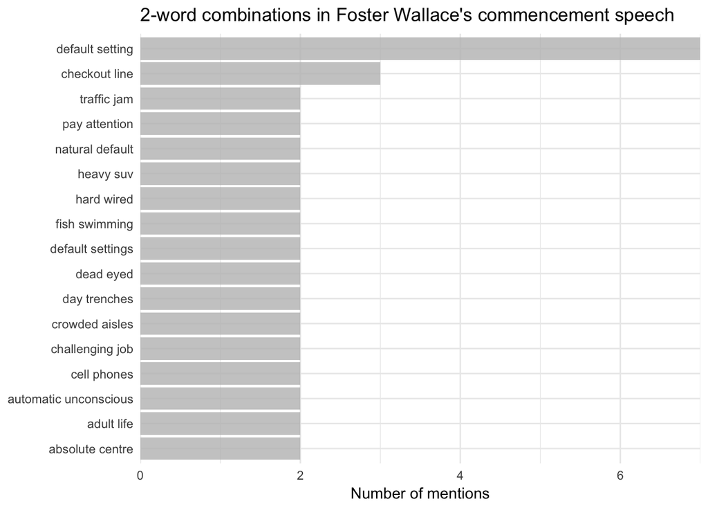

```r
bigram %>% count(word, sort = TRUE) %>% top_n(10) %>% mutate(word = reorder(word,
    n)) %>% ggplot(aes(word, n)) + geom_col(fill = "grey", alpha = 0.8) + coord_flip() +
    scale_y_continuous(expand = c(0, 0)) + labs(x = NULL, y = "Number of mentions",
    title = "2-word combinations in Foster Wallace's commencement speech") +
    theme_minimal()
```

#### Sentiment analysis

**Frequency of positive words**

```r
words %>% inner_join(get_sentiments("bing"), by = "word") %>% filter(sentiment ==
    "positive") %>% count(word) %>% wordcloud2(size = 0.7, fontFamily = "RobotoCondensed-Regular",
    color = rep(c("orange", "skyblue"), length.out = nrow(.)))
```

[interactive chart not shown]

**Frequency of negative words**

```r
words %>% inner_join(get_sentiments("bing"), by = "word") %>% filter(sentiment ==
    "negative") %>% count(word) %>% wordcloud2(size = 0.7, fontFamily = "RobotoCondensed-Regular",
    color = rep(c("black", "grey"), length.out = nrow(.)))
```

[interactive chart not shown]

**Distribution of positive and negative words**

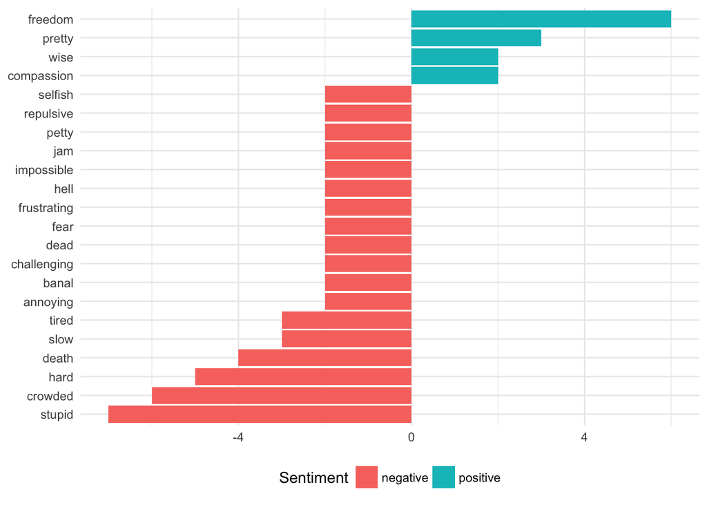

```r
words %>% inner_join(get_sentiments("bing"), by = "word") %>% count(word, sentiment,
    sort = TRUE) %>% ungroup() %>% filter(n > 1) %>% mutate(n = ifelse(sentiment ==
    "negative", -n, n)) %>% mutate(word = reorder(word, n)) %>% ggplot(aes(word,
    n, fill = sentiment)) + geom_col() + labs(x = NULL, y = NULL, fill = "Sentiment") +
    coord_flip() + theme_minimal() + theme(legend.position = "bottom")
```

### Resources

- Silge, J. & Robinson, D. (2017). Text Mining with R: A Tidy Approach, O’Reilly Media. Available online via: http://tidytextmining.com